# DATS 6101 - Midterm

#### Visualization for Category vs. App Size

```r
#convert_size <- function(size) {
#    size <- gsub(",", "", size)  # Remove commas
#    size <- tolower(size)  # Make lowercase for consistency

      # Handle "varies with device" by assigning NA
#    if (size == "varies with device") return(NA)

      # Convert "k" to MB (1 MB = 1000 KB)
 #   if (grepl("k", size)) return(as.numeric(gsub("k", "", size)) / 1000)

      # Convert "M" to numeric MB
  #  if (grepl("m", size)) return(as.numeric(gsub("m", "", size)))

      # Handle numeric values directly (e.g., "1000+")
   # if (grepl("\\d+\\+", size)) return(as.numeric(gsub("\\+", "", size)) / 1000)

      # Default case: return as numeric if possible
    #return(as.numeric(size))
    #}
```

Below is the figure showing the distribution of app sizes in each category.

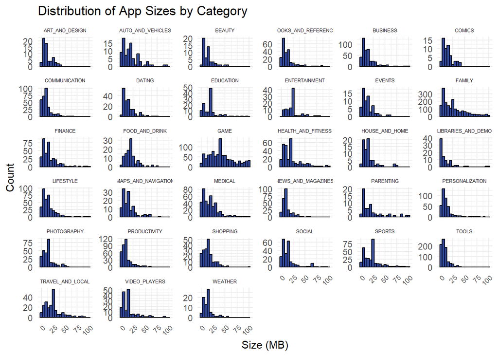

```r
#df_clean <- data_clean %>%
 # mutate(Size = sapply(Size, convert_size)) %>%
#  filter(!is.na(Size))

# Plot the histogram with faceting by category
ggplot(data_clean, aes(x = Size)) +
  geom_histogram(binwidth = 5, fill = "#304ba6", color = "black") +
  facet_wrap(~ Category, scales = "free_y") +
  theme_minimal() +
  labs(
    title = "Distribution of App Sizes by Category",
    x = "Size (MB)",
    y = "Count"
  ) +
  theme(
    strip.text = element_text(size = 5),
    axis.text.x = element_text(size = 7, angle = 45, hjust = 1)
  )
```

```r
str(data_clean)
```

```
## 'data.frame':    9659 obs. of  13 variables:
##  $ App           : chr  "Photo Editor & Candy Camera & Grid & ScrapBook" "Coloring book moana" "U Launcher Lite – FREE Live Cool Themes, Hide Apps" "Sketch - Draw & Paint" ...
##  $ Category      : chr  "ART_AND_DESIGN" "ART_AND_DESIGN" "ART_AND_DESIGN" "ART_AND_DESIGN" ...
##  $ Rating        : num  4.1 3.9 4.7 4.5 4.3 4.4 3.8 4.1 4.4 4.7 ...
##  $ Reviews       : num  159 967 87510 215644 967 ...
##  $ Size          : num  19 14 8.7 25 2.8 5.6 19 29 33 3.1 ...
##  $ Installs      : num  1e+04 5e+05 5e+06 5e+07 1e+05 5e+04 5e+04 1e+06 1e+06 1e+04 ...
##  $ Type          : chr  "Free" "Free" "Free" "Free" ...
##  $ Price         : num  0 0 0 0 0 0 0 0 0 0 ...
##  $ Content.Rating: chr  "Everyone" "Everyone" "Everyone" "Teen" ...
##  $ Genres        : chr  "Art & Design" "Art & Design;Pretend Play" "Art & Design" "Art & Design" ...
##  $ Last.Updated  : chr  "January 7, 2018" "January 15, 2018" "August 1, 2018" "June 8, 2018" ...
##  $ Current.Ver   : chr  "1.0.0" "2.0.0" "1.2.4" "Varies with device" ...
##  $ Android.Ver   : chr  "4.0.3 and up" "4.0.3 and up" "4.0.3 and up" "4.2 and up" ...
```

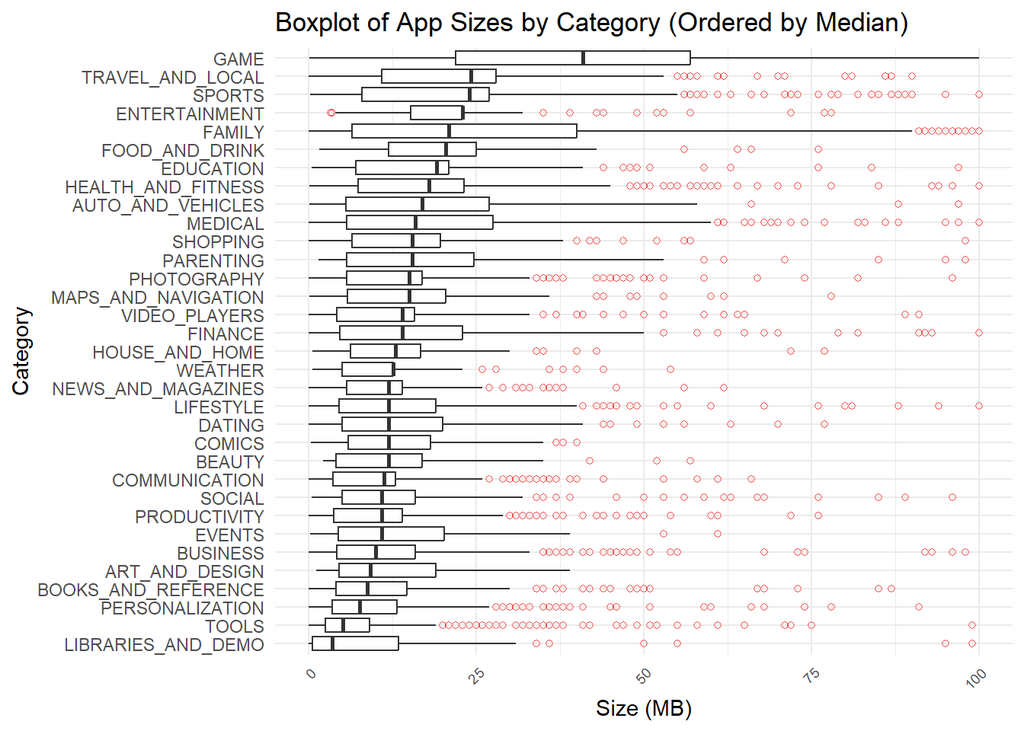

```r
ggplot(data_clean, aes(x = reorder(Category, Size, FUN = median), y = Size)) +
  geom_boxplot(outlier.color = "#f05555", outlier.shape = 1) +
  coord_flip() +
  theme_minimal() +
  labs(
    title = "Boxplot of App Sizes by Category (Ordered by Median)",
    x = "Category",
    y = "Size (MB)"
  ) +
  theme(
    strip.text = element_text(size = 8),
    axis.text.x = element_text(size = 7, angle = 45, hjust = 1)
  )
```

As it can be seen from the two figures above, most categories exhibit right-skewed app sizes, with the majority being under 50MB. However, the Game category stands out with a significantly larger median app size compared to other categories.

#### Visualization for Category vs. Reviews

Below is the graph displaying the distribution of reviews left by users for each category.

```r
df_aggregated <- data_final %>%
  group_by(Category) %>%
  summarise(Total_Reviews = sum(Reviews, na.rm = TRUE))

#df_aggregated
```

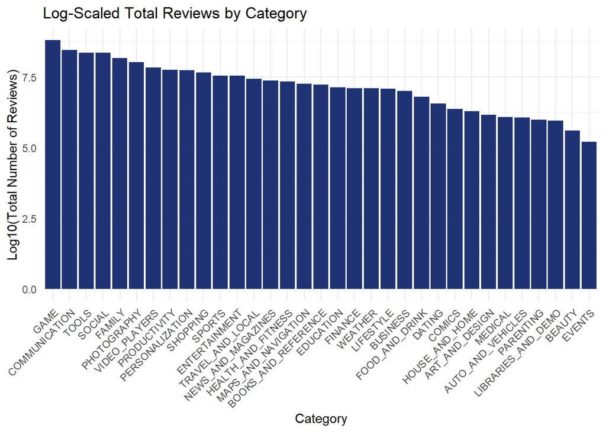

```r
# Plot the total reviews by category using a bar chart
ggplot(df_aggregated, aes(x = reorder(Category, -Total_Reviews), y = log10(Total_Reviews))) +
  geom_bar(stat = "identity", fill = "#1f3374") +
  labs(
    title = "Log-Scaled Total Reviews by Category",
    x = "Category",
    y = "Log10(Total Number of Reviews)"
  ) +
  theme_minimal() +
  theme(axis.text.x = element_text(angle = 45, hjust = 1))
```

AS it can be seen that game apps have most reviews while events apps have the least reviews.

#### Histogram for Category vs. Rating

Below is the figure demonstrating the distribution of number of rating for each category.

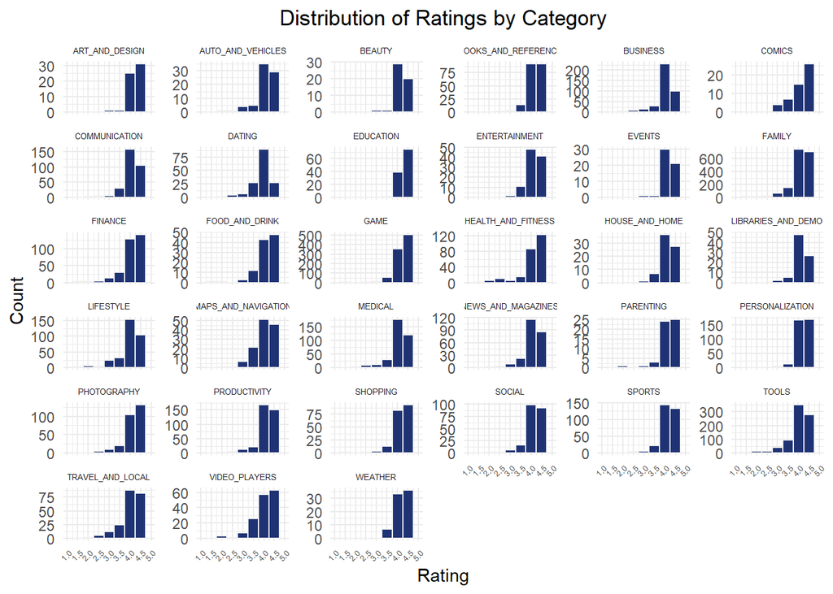

```r
ggplot(data_final, aes(x = Rating)) +
  geom_histogram(binwidth = 0.5, fill = "#1f3374", color='#efefef') +
  facet_wrap(~ Category, scales = "free_y") +  # Facet by Category with independent y-axis
  scale_x_continuous(limits = c(1, 5), breaks = seq(1, 5, by = 0.5)) +  # Restrict x-axis to 1-5
  theme_minimal() +
  labs(
    title = "Distribution of Ratings by Category",
    x = "Rating",
    y = "Count"
  ) +
  theme(
    strip.text = element_text(size = 5),  # Adjust facet label size
    axis.text.x = element_text(size = 5, angle = 45, hjust = 1),  # Rotate x-axis labels
    plot.title = element_text(hjust = 0.5)  # Center the plot title
  )
```

#### Visualization for Android Version

Below is the figure showing the distribution of Android versions.

```r
df_clean <- data_final %>%
  filter(!is.na(Android.Ver) & !is.na(Reviews) & !(Android.Ver == 'NaN'))
```

```r
extract_version <- function(version) {
  version <- tolower(version)  # Make lowercase for consistency

  # Handle "Varies with device" and "NaN"
  if (version == "varies with device" || version == "nan") return(NA)

  # Extract the first version in case of ranges (e.g., "4.1 - 7.1.1" -> "4.1")
  first_version <- strsplit(version, "[- ]")[[1]][1]

  # Remove "and up" if present (e.g., "4.0 and up" -> "4.0")
  first_version <- gsub("and up", "", first_version)

  return(as.numeric(first_version))  # Convert to numeric
}
```

```r
df_clean <- data_final %>%
  mutate(Android_Ver = sapply(Android.Ver, extract_version)) %>%
  filter(!is.na(Android_Ver))  # Remove rows with NA in Android_Ver

android_installs <- data_final %>%
  group_by(Android.Ver) %>%
  summarize(Total_Installs = sum(Installs, na.rm = TRUE))
```

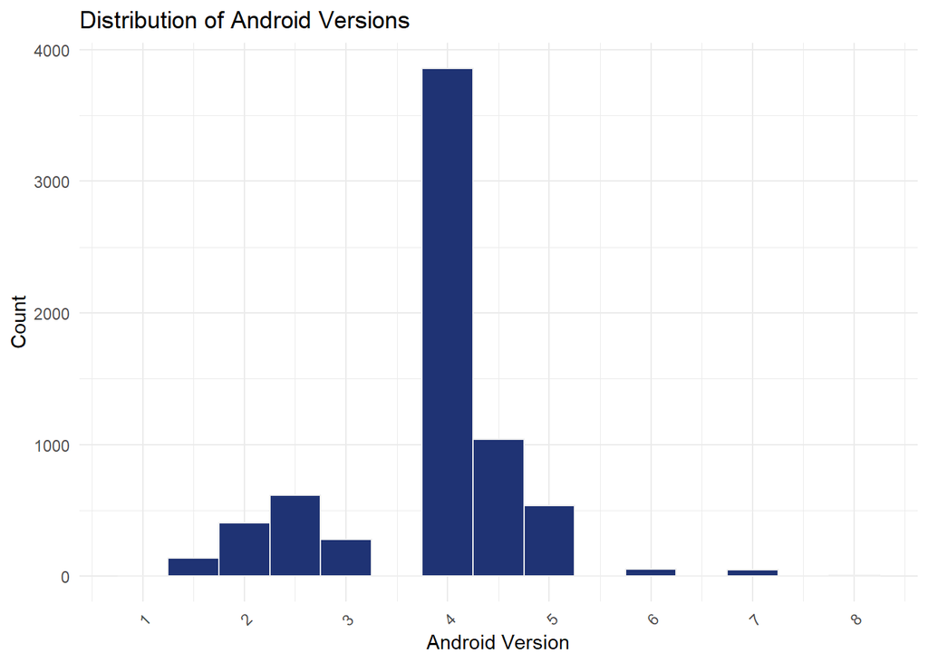

```r
ggplot(df_clean, aes(x = Android_Ver)) +
  geom_histogram(binwidth = 0.5, fill = "#1f3374", color='#efefef') +
  scale_x_continuous(breaks = seq(1, 8, by = 1.0)) +  # Set x-axis ticks from 1.0 to 8.0
  theme_minimal() +
  labs(
    title = "Distribution of Android Versions",
    x = "Android Version",
    y = "Count"
  ) +
  theme(axis.text.x = element_text(angle = 45, hjust = 1))
```

As it can be seen that, the minimum required Android Version for most apps is 4.0 and up.

```r
extract_version <- function(version) {
  version <- tolower(version)  # Make lowercase for consistency

  # Handle "Varies with device" and "NaN"
  if (version == "varies with device" || version == "nan") return(NA)

  # Extract the first version in case of ranges (e.g., "4.1 - 7.1.1" -> "4.1")
  first_version <- strsplit(version, "[- ]")[[1]][1]

  # Remove "and up" if present (e.g., "4.0 and up" -> "4.0")
  first_version <- gsub("and up", "", first_version)

  return(as.numeric(first_version))  # Convert to numeric
}
```

#### Bar plot for Android Version vs. Installs

Below is the graph showing the number of installs for each minimum required Android Version.

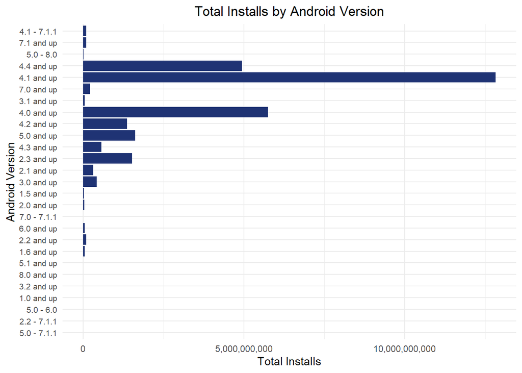

```r
ggplot(df_clean, aes(x = reorder(Android.Ver, Installs), y = Installs)) +
  geom_bar(stat = "identity", fill = "#1f3374") +
  coord_flip() +  # Flip coordinates for better readability
  scale_y_continuous(labels = scales::comma) +  # Format y-axis with commas
  theme_minimal() +
  labs(
    title = "Total Installs by Android Version",
    x = "Android Version",
    y = "Total Installs"
  ) +
  theme(
    axis.text.y = element_text(size = 8),  # Adjust y-axis text size
    plot.title = element_text(hjust = 0.5)  # Center the plot title
  )
```

#### Boxplot for Android Version vs. Reviews

Below is the distribution of reviews for each minimum required Android Version.

```r
df_clean <- data_final %>%
  filter(!is.na(Android.Ver) & !is.na(Reviews) & !(Android.Ver == 'NaN')) %>%
  mutate(Scaled_Reviews = log10(Reviews + 1))
```

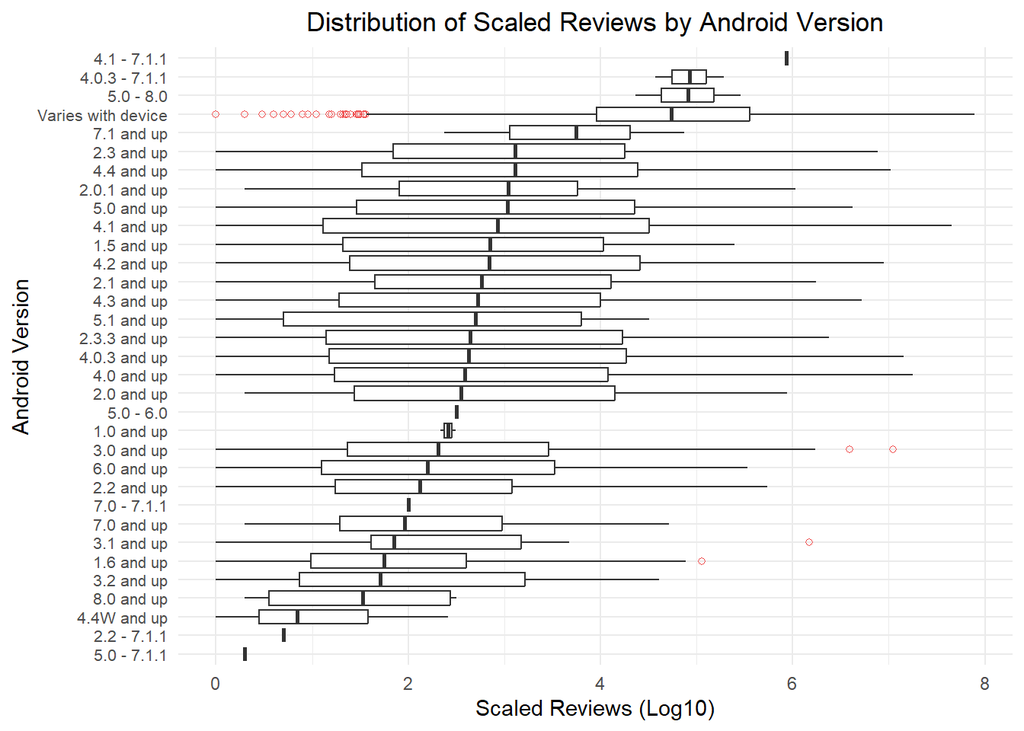

```r
ggplot(df_clean, aes(x = reorder(Android.Ver, Scaled_Reviews, FUN = median), y = Scaled_Reviews)) +
  geom_boxplot(outlier.color = "#f05555", outlier.shape = 1) +  # Boxplot with red outliers
  coord_flip() +  # Flip coordinates for better readability
  theme_minimal() +
  labs(
    title = "Distribution of Scaled Reviews by Android Version",
    x = "Android Version",
    y = "Scaled Reviews (Log10)"
  ) +
  theme(
    axis.text.y = element_text(size = 8),  # Adjust y-axis text size
    plot.title = element_text(hjust = 0.5)  # Center the plot title
  )
```

It can be seen that the version from 4.1 to 7.1.1 have the highest number of reviews, whiel version from 5.0 to 7.1.1 have the least number of reviews.

#### Histogram for Android Version vs. Rating

Below is the plot showing the number of ratings for each Android Version.

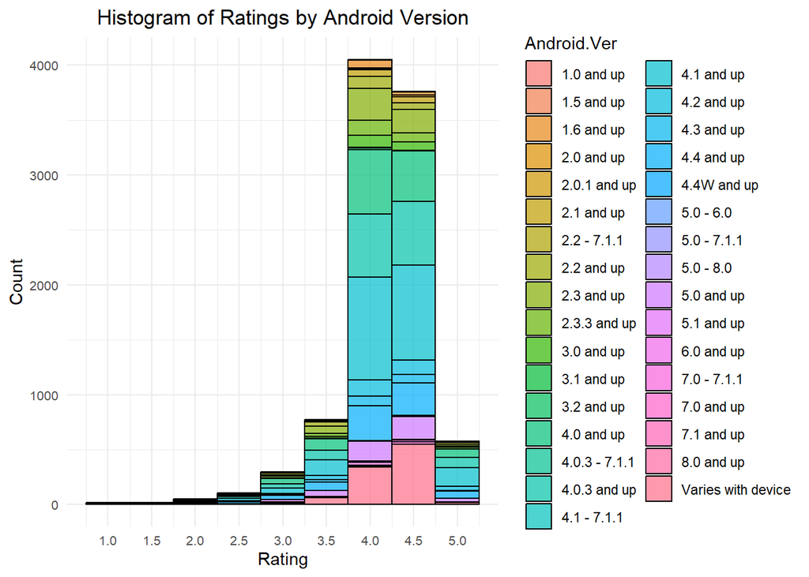

```r
ggplot(df_clean, aes(x = Rating, fill = Android.Ver)) +
  geom_histogram(binwidth = 0.5, position = "stack", color = "black", alpha = 0.7) +
  scale_x_continuous(breaks = seq(1, 5, by = 0.5)) +  # Set x-axis breaks
  theme_minimal() +
  labs(
    title = "Histogram of Ratings by Android Version",
    x = "Rating",
    y = "Count"
  ) +
  theme(
    axis.text.x = element_text(size = 8),
    axis.text.y = element_text(size = 8),
    plot.title = element_text(hjust = 0.5)  # Center the plot title
  )
```

It can be seen that most Android Version have ratings range between 4.0 and 5.0.

#### Distribution for Content.Rating

```r
# Clean and prepare the Last Updated  and Content column
data_updated <- data_final %>%
  mutate(
    Content.Rating = as.factor(Content.Rating)
  )

# 1. Content Rating Distribution
content_rating_dist <- table(data_updated$Content.Rating)
print("Content Rating Distribution:")
```

```
## [1] "Content Rating Distribution:"
```

```r
print(content_rating_dist)
```

```
##
## adults only 18+        everyone    everyone 10+      mature 17+            teen
##               3            7903             322             393            1036
##         unrated
##               2
```

#### Visualization for Content Rating

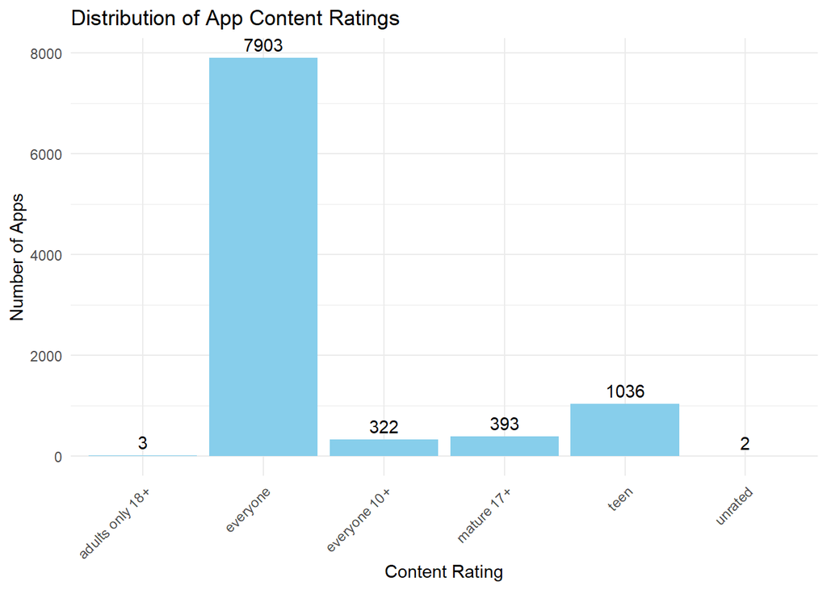

```r
# Bar plot for Content Rating
ggplot(data_final, aes(x = Content.Rating)) +
  geom_bar(fill = "skyblue") +
  geom_text(stat = "count", aes(label = ..count..), vjust = -0.5) +
  labs(title = "Distribution of App Content Ratings",
       x = "Content Rating",
       y = "Number of Apps") +
  theme_minimal() +
  theme(axis.text.x = element_text(angle = 45, hjust = 1))
```

```r
# Last Updated Analysis
# Create summary of updates by month and year
updates_by_month <- data_updated %>%
  mutate(
    update_month = format(Last.Updated, "%Y-%m"),
    update_year = year(Last.Updated)
  ) %>%
  group_by(update_month) %>%
  summarize(count = n()) %>%
  arrange(update_month)
```

```r
# Plot updates over time
#ggplot(updates_by_month, aes(x = as.Date(paste0(update_month, "-01")), y = count)) +
  #geom_line(color = "blue") +
  #geom_point(color = "red") +
  #labs(title = "Number of App Updates Over Time",
  #     x = "Date",
  #     y = "Number of Updates") +
  #theme_minimal() +
 # theme(axis.text.x = element_text(angle = 45, hjust = 1))
```

```r
# Content Rating and Update Frequency Relationship
update_frequency_by_rating <- data_updated %>%
  group_by(Content.Rating) %>%
  summarize(
    avg_last_update = mean(Last.Updated),
    median_last_update = median(Last.Updated),
    n_apps = n()
  )
print("\nUpdate Frequency by Content Rating:")
```

```
## [1] "\nUpdate Frequency by Content Rating:"
```

```r
print(update_frequency_by_rating)
```

```
## # A tibble: 6 × 4
##   Content.Rating  avg_last_update median_last_update n_apps
##   <fct>           <date>          <date>              <int>
## 1 adults only 18+ 2018-07-20      2018-07-24              3
## 2 everyone        2017-10-20      2018-04-20           7903
## 3 everyone 10+    2017-11-24      2018-06-06            322
## 4 mature 17+      2018-02-18      2018-07-09            393
## 5 teen            2017-12-03      2018-06-05           1036
## 6 unrated         2013-10-25      2013-10-25              2
```

```r
# Basic statistics for Installs by Content Rating
installs_by_rating <- data_updated %>%
  group_by(Content.Rating) %>%
  summarise(
    mean_installs = mean(Installs, na.rm = TRUE),
    median_installs = median(Installs, na.rm = TRUE),
    total_installs = sum(Installs, na.rm = TRUE),
    n_apps = n()
  ) %>%
  arrange(desc(mean_installs))

print("Summary of Installs by Content Rating:")
```

```
## [1] "Summary of Installs by Content Rating:"
```

```r
print(installs_by_rating)
```

```
## # A tibble: 6 × 5
##   Content.Rating  mean_installs median_installs total_installs n_apps
##   <fct>                   <dbl>           <dbl>          <dbl>  <int>
## 1 teen                15914358.          500000    16487275393   1036
## 2 everyone 10+        12472894.         1000000     4016271795    322
## 3 everyone             6602474.           50000    52179352961   7903
## 4 mature 17+           6203529.          500000     2437986878    393
## 5 adults only 18+       666667.          500000        2000000      3
## 6 unrated                25250            25250          50500      2
```

```r
# Basic statistics for Ratings by Content Rating
ratings_by_content <- data_updated %>%
  group_by(Content.Rating) %>%
  summarise(
    mean_rating = mean(Rating, na.rm = TRUE),
    median_rating = median(Rating, na.rm = TRUE),
    total_ratings = sum(Rating, na.rm = TRUE),
    n_apps = n()
  ) %>%
  arrange(desc(mean_rating))

print("Summary of Ratings by Content Rating:")
```

```
## [1] "Summary of Ratings by Content Rating:"
```

```r
print(ratings_by_content)
```

```
## # A tibble: 6 × 5
##   Content.Rating  mean_rating median_rating total_ratings n_apps
##   <fct>                 <dbl>         <dbl>         <dbl>  <int>
## 1 adults only 18+        4.3           4.5          12.9       3
## 2 everyone 10+           4.22          4.3        1360.      322
## 3 teen                   4.22          4.2        4371.     1036
## 4 everyone               4.17          4.2       32935.     7903
## 5 unrated                4.14          4.14          8.27      2
## 6 mature 17+             4.13          4.2        1622.      393
```

```r
# Basic statistics for Reviews by Content Rating
reviews_by_content <- data_updated %>%
  group_by(Content.Rating) %>%
  summarise(
    mean_reviews = mean(Reviews, na.rm = TRUE),
    median_reviews = median(Reviews, na.rm = TRUE),
    total_reviews = sum(Reviews, na.rm = TRUE),
    n_apps = n()
  ) %>%
  arrange(desc(mean_reviews))

print("Summary of Reviews by Content Rating:")
```

```
## [1] "Summary of Reviews by Content Rating:"
```

```r
print(reviews_by_content)
```

```
## # A tibble: 6 × 5
##   Content.Rating  mean_reviews median_reviews total_reviews n_apps
##   <fct>                  <dbl>          <dbl>         <dbl>  <int>
## 1 everyone 10+         625243.         19023      201328121    322
## 2 teen                 485803.         10144      503292211   1036
## 3 mature 17+           221471.          3414       87038201    393
## 4 everyone             164536.           573     1300326506   7903
## 5 adults only 18+       27116          24005          81348      3
## 6 unrated                 594.           594.          1187      2
```

```r
# Required libraries
library(dplyr)
library(tidyr)
library(lubridate)
library(ggplot2)
library(reshape2)

# Create days_since_update and data preparation
data_updated <- data_final %>%
  mutate(
    # Convert Last.Updated to proper date format (assuming it's in standard format)
    last_updated = as.Date(Last.Updated),
    current_date = Sys.Date(),
    # Calculate days since last update
    days_since_update = as.numeric(difftime(current_date, last_updated, units = "days")),
    # Extract month from last_updated date
    update_month = month(last_updated)
  ) %>%
  # Remove any invalid dates or NA values
  filter(!is.na(last_updated), !is.na(days_since_update))

# Create subset for update analysis
data_updated <- data_updated %>% filter(!is.na(days_since_update))

# Calculate update statistics by Content Rating
update_patterns <- data_updated %>%
  group_by(Content.Rating) %>%
  summarize(
    avg_days_since_update = mean(days_since_update, na.rm = TRUE),
    median_days_since_update = median(days_since_update, na.rm = TRUE),
    sd_days_since_update = sd(days_since_update, na.rm = TRUE),
    n_apps = n(),
    cv = sd_days_since_update / avg_days_since_update * 100  # Coefficient of Variation
  ) %>%
  arrange(avg_days_since_update)

print("\nUpdate Patterns by Content Rating:")
```

```
## [1] "\nUpdate Patterns by Content Rating:"
```